# reslr: quick start guide

Maeve Upton, Andrew Parnell and Niamh Cahill

2026-05-26

## Step 1: install `reslr`

Use:

```r
#install.packages("reslr")
#devtools::install_github("maeveupton/reslr")
install_github("maeveupton/reslr")
```

then,

```r
library(reslr)
```

Note: The JAGS software is a requirement for this instruction sheet and refer back to main vignettes for more information.

## Step 2: load in the data into `reslr`

```r
path_to_data <- system.file("extdata", "one_data_site_ex.csv", package = "reslr")
example_one_datasite <- read.csv(path_to_data)
```

Using the `reslr_load` function to read in the data into the `reslr` package:

```r
example_one_site_input <- reslr_load(
  data = example_one_datasite)
```

## Step 3: plot the data

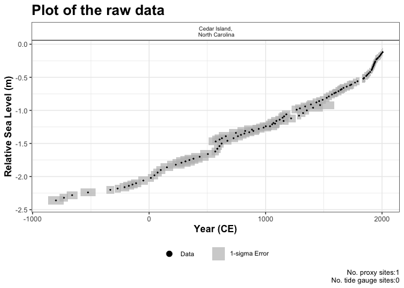

```r
plot(
  x = example_one_site_input,
  title = "Plot of the raw data",
  xlab = "Year (CE)",
  ylab = "Relative Sea Level (m)",
  plot_tide_gauges = FALSE,
  plot_caption = TRUE
)
```

## Step 4: Run your statistical model and check convergence

Select your modelling technique from the modelling options available:

[output not shown]

For this example, it is a single site and we are interested in how it varies over time select the Noisy Input spline in time. If it was multiple sites, we recommend using a spatial temporal model, i.e. Noisy Input spline in space and time, or for decomposing the signal, i.e. Noisy Input Generalised Additive model.

Once the model is chosen use the `reslr_mcmc` function to run it:

```r
res_one_site_example <- reslr_mcmc(
  input_data = example_one_site_input,
  model_type = "ni_spline_t",
  CI = 0.95
)
```

The convergence of the algorithm is examined and he parameter estimates from the model can be investigated using the following:

```r
summary(res_one_site_example)
```

```
#> No convergence issues detected.
#> # A tibble: 2 × 7
#>   variable      mean      sd     mad       q5    q95  rhat
#>   <chr>        <dbl>   <dbl>   <dbl>    <dbl>  <dbl> <dbl>
#> 1 sigma_beta 2.07    0.663   0.536   1.28     3.37   1.000
#> 2 sigma_y    0.00622 0.00471 0.00464 0.000525 0.0153 1.000
```

## Step 5: Plot the results

The model fit results can be visualised using the following function:

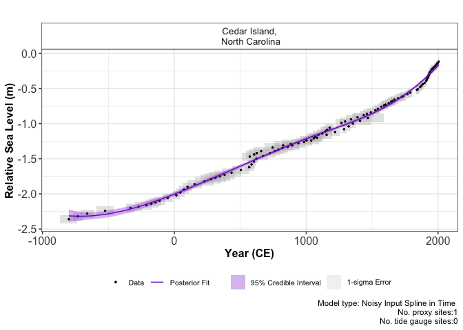

```r
plot(res_one_site_example,
  xlab = "Year (CE)",
  ylab = "Relative Sea Level (m)",
  plot_type = "model_fit_plot"
)
```

For the rate of change plot use:

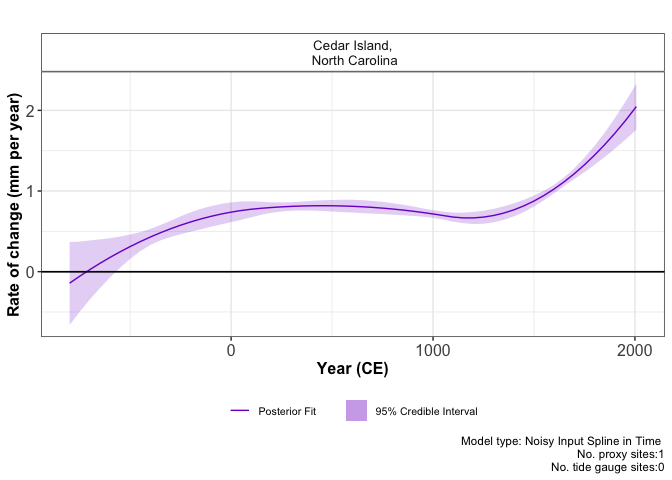

```r
plot(res_one_site_example,
  plot_type = "rate_plot"
)
```

To examine the data creating these plots the user types the following:

```r
output_dataframes <- res_one_site_example$output_dataframes
head(output_dataframes)
```

```
#>   Longitude Latitude                       SiteName data_type_id  Age      pred
#> 1    -76.38   34.971 Cedar Island,\n North Carolina  ProxyRecord -800 -2.312253
#> 2    -76.38   34.971 Cedar Island,\n North Carolina  ProxyRecord -750 -2.317222
#> 3    -76.38   34.971 Cedar Island,\n North Carolina  ProxyRecord -700 -2.317994
#> 4    -76.38   34.971 Cedar Island,\n North Carolina  ProxyRecord -650 -2.314775
#> 5    -76.38   34.971 Cedar Island,\n North Carolina  ProxyRecord -600 -2.307773
#> 6    -76.38   34.971 Cedar Island,\n North Carolina  ProxyRecord -550 -2.297192
#>         upr       lwr   rate_pred    rate_upr  rate_lwr  CI
#> 1 -2.395207 -2.221821 -0.14271283 -0.66096585 0.3667582 95%
#> 2 -2.382841 -2.245119 -0.05671909 -0.49728706 0.3732595 95%
#> 3 -2.375112 -2.259213  0.02515111 -0.34564049 0.3874031 95%
#> 4 -2.365446 -2.263507  0.10289755 -0.20476239 0.4001855 95%
#> 5 -2.356353 -2.261148  0.17652023 -0.07178998 0.4157362 95%
#> 6 -2.346780 -2.250354  0.24601915  0.04973288 0.4359669 95%
```

To examine the additional options in the `reslr` package, see the main vignette.